# Predicting Flu Rates in Paris

dfox

6/24/2022

## Exploratory Analysis

We can begin our analysis of the flu rates in Paris by plotting our time series data. This set contains data from 2004-2013; capturing the flu rate once a week for those years.

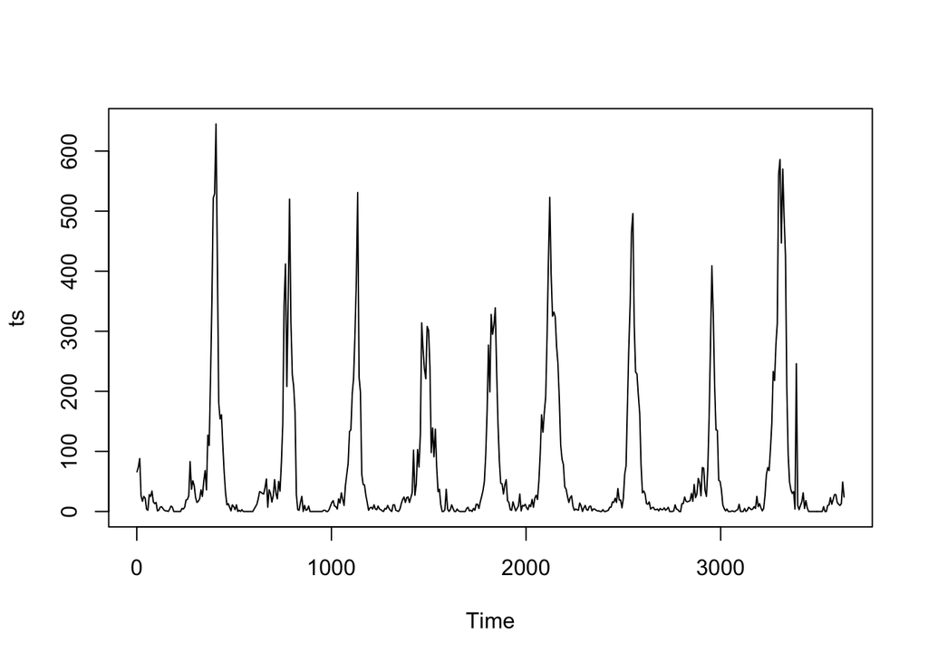

As shown in the plot, Paris sees a rather consistent trend over the course of this decade. The rates look fairly low for about a year, then quickly increase, and followed by quickly decreasing again. Since we are investing flu rates, we can use outside knowledge of the fact that rates tend to spike in the winter months; therefore, our data will most likely reflect that. Judging by the consistent trend over this decade, this remains true.

To continue our analysis, let’s try detrending and differencing the data.

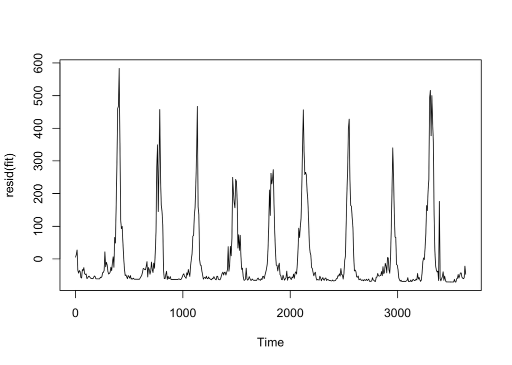

```r
# detrending
fit <- lm(ts ~ time(ts), na.action=NULL)
ts.plot(resid(fit))
```

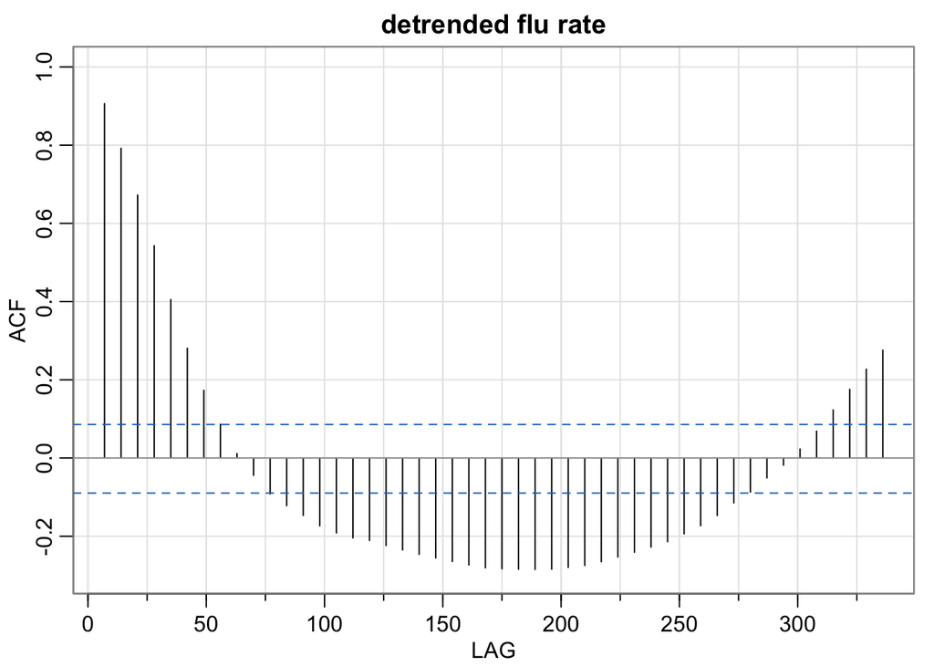

```
##  [1]  0.91  0.79  0.67  0.54  0.41  0.28  0.17  0.09  0.01 -0.04 -0.09 -0.12
## [13] -0.15 -0.17 -0.19 -0.20 -0.21 -0.22 -0.24 -0.25 -0.26 -0.26 -0.27 -0.28
## [25] -0.28 -0.28 -0.28 -0.28 -0.28 -0.27 -0.27 -0.25 -0.24 -0.23 -0.21 -0.19
## [37] -0.17 -0.15 -0.11 -0.09 -0.05 -0.02  0.02  0.07  0.12  0.18  0.23  0.28
```

```r
acf1(resid(fit), 48, main="detrended flu rate")
```

Now, differencing.

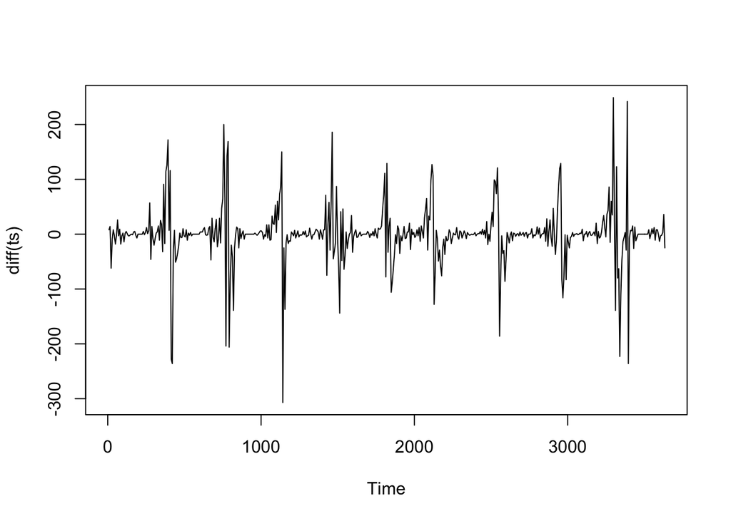

```r
# differencing
ts.plot(diff(ts))
```

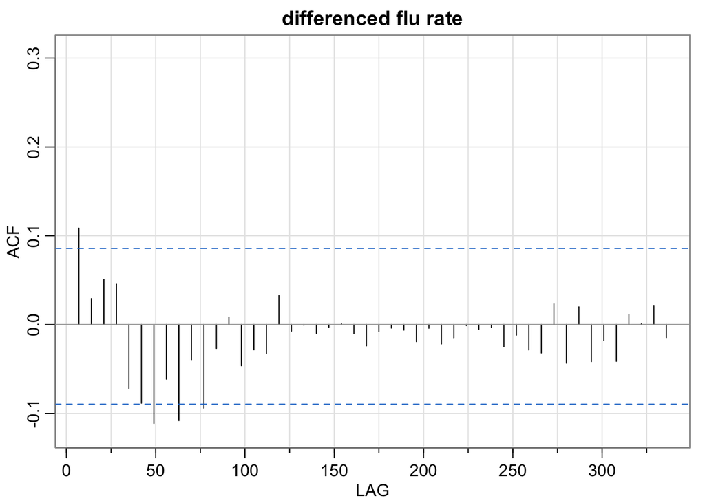

```
##  [1]  0.11  0.03  0.05  0.05 -0.07 -0.09 -0.11 -0.06 -0.11 -0.04 -0.09 -0.03
## [13]  0.01 -0.05 -0.03 -0.03  0.03 -0.01  0.00 -0.01  0.00  0.00 -0.01 -0.02
## [25] -0.01  0.00 -0.01 -0.02  0.00 -0.02 -0.01  0.00 -0.01  0.00 -0.02 -0.01
## [37] -0.03 -0.03  0.02 -0.04  0.02 -0.04 -0.02 -0.04  0.01  0.00  0.02 -0.01
```

```r
acf1(diff(ts), 48, main="differenced flu rate")
```

The goal of detrending or differencing is coerce our data into being stationary. We can see that detrending the data doesn’t exactly accomplish much. But, differencing the data does accomplish what we’d like. This lets us know that we should potentiall use our differenced data in our modeling.

## ARIMA Model

After exploring the data, we can move into modeling our data. We start with using an ARIMA model. This will use auto regressive functions with integrating the moving average of our data.

We start with using the auto.arima() function that will help determine the parameter of our ARIMA model.

```r
auto.arima(diff(ts), seasonal=FALSE)
```

```
## Series: diff(ts)
## ARIMA(0,0,1) with zero mean
##
## Coefficients:
##          ma1
##       0.1049
## s.e.  0.0429
##
## sigma^2 estimated as 2556:  log likelihood=-2772.05
## AIC=5548.1   AICc=5548.12   BIC=5556.6
```

```r
auto.arima(ts, seasonal=FALSE)
```

```
## Series: ts
## ARIMA(2,0,3) with non-zero mean
##
## Coefficients:
##          ar1      ar2      ma1      ma2     ma3     mean
##       1.6710  -0.7354  -0.6621  -0.0044  0.0837  65.7575
## s.e.  0.1433   0.1184   0.1449   0.0605  0.0659  13.6234
##
## sigma^2 estimated as 2338:  log likelihood=-2752.61
## AIC=5519.22   AICc=5519.44   BIC=5549
```

By running this command, we can see that we our model should be ARIMA(2, 0, 3). Let’s take a look.

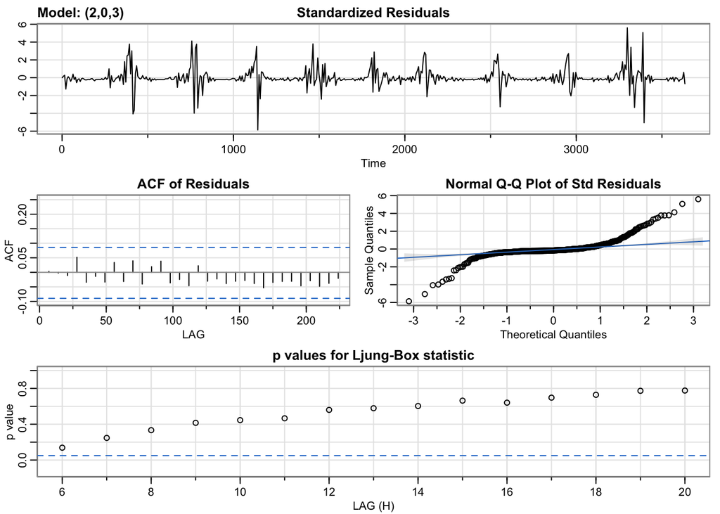

```
## $fit
##
## Call:
## arima(x = xdata, order = c(p, d, q), seasonal = list(order = c(P, D, Q), period = S),
##     xreg = xmean, include.mean = FALSE, transform.pars = trans, fixed = fixed,
##     optim.control = list(trace = trc, REPORT = 1, reltol = tol))
##
## Coefficients:
##          ar1      ar2      ma1      ma2     ma3    xmean
##       1.6710  -0.7354  -0.6621  -0.0044  0.0837  65.7575
## s.e.  0.1433   0.1184   0.1449   0.0605  0.0659  13.6234
##
## sigma^2 estimated as 2311:  log likelihood = -2752.61,  aic = 5519.22
##
## $degrees_of_freedom
## [1] 514
##
## $ttable
##       Estimate      SE t.value p.value
## ar1     1.6710  0.1433 11.6624  0.0000
## ar2    -0.7354  0.1184 -6.2108  0.0000
## ma1    -0.6621  0.1449 -4.5696  0.0000
## ma2    -0.0044  0.0605 -0.0722  0.9424
## ma3     0.0837  0.0659  1.2696  0.2048
## xmean  65.7575 13.6234  4.8268  0.0000
##
## $AIC
## [1] 10.61389
##
## $AICc
## [1] 10.61421
##
## $BIC
## [1] 10.67115
```

```r
sarima(ts, p=2, d=0, q=3)
```

## SARIMA Model

Next, we can use a similar process for finding our SARIMA model.

```r
auto.arima(ts, seasonal=TRUE)
```

```
## Series: ts
## ARIMA(2,0,3) with non-zero mean
##
## Coefficients:
##          ar1      ar2      ma1      ma2     ma3     mean
##       1.6710  -0.7354  -0.6621  -0.0044  0.0837  65.7575
## s.e.  0.1433   0.1184   0.1449   0.0605  0.0659  13.6234
##
## sigma^2 estimated as 2338:  log likelihood=-2752.61
## AIC=5519.22   AICc=5519.44   BIC=5549
```

## Mixed SARIMA Model

Finally, let’s find a mixed SARIMA Model.

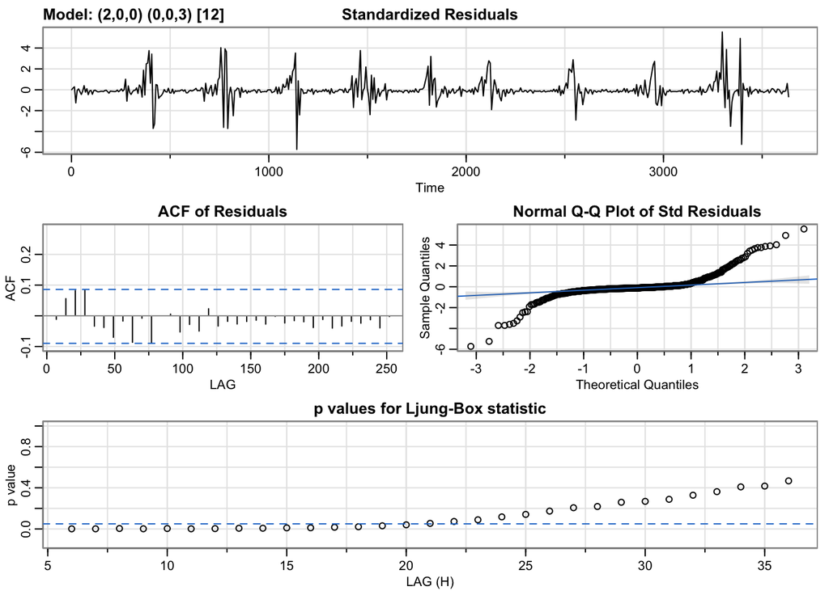

```
## $fit
##
## Call:
## arima(x = xdata, order = c(p, d, q), seasonal = list(order = c(P, D, Q), period = S),
##     xreg = xmean, include.mean = FALSE, transform.pars = trans, fixed = fixed,
##     optim.control = list(trace = trc, REPORT = 1, reltol = tol))
##
## Coefficients:
##          ar1      ar2     sma1     sma2     sma3    xmean
##       1.0477  -0.1611  -0.0217  -0.0388  -0.0149  65.3662
## s.e.  0.0435   0.0434   0.0437   0.0440   0.0458  17.3247
##
## sigma^2 estimated as 2385:  log likelihood = -2760.71,  aic = 5535.43
##
## $degrees_of_freedom
## [1] 514
##
## $ttable
##       Estimate      SE t.value p.value
## ar1     1.0477  0.0435 24.0734  0.0000
## ar2    -0.1611  0.0434 -3.7145  0.0002
## sma1   -0.0217  0.0437 -0.4963  0.6199
## sma2   -0.0388  0.0440 -0.8815  0.3784
## sma3   -0.0149  0.0458 -0.3261  0.7445
## xmean  65.3662 17.3247  3.7730  0.0002
##
## $AIC
## [1] 10.64506
##
## $AICc
## [1] 10.64537
##
## $BIC
## [1] 10.70232
```

```r
sarima(ts, p=2, d=0, q=0, P=0, D=0, Q=3, 12)
```

## Model Selection

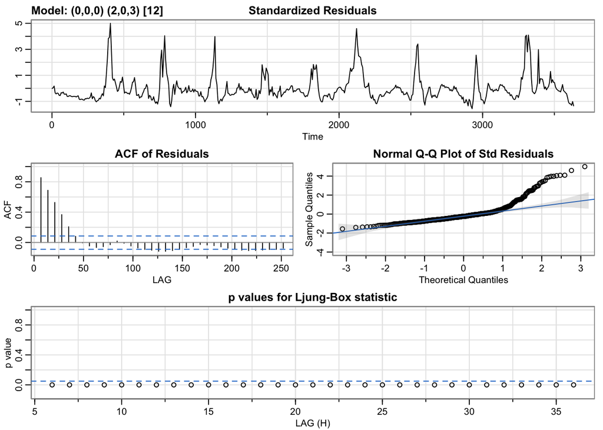

```
## $fit
##
## Call:
## arima(x = xdata, order = c(p, d, q), seasonal = list(order = c(P, D, Q), period = S),
##     xreg = xmean, include.mean = FALSE, transform.pars = trans, fixed = fixed,
##     optim.control = list(trace = trc, REPORT = 1, reltol = tol))
##
## Coefficients:
##         sar1     sar2     sma1    sma2     sma3    xmean
##       0.2434  -0.9985  -0.5236  1.0652  -0.3166  67.3580
## s.e.  0.0123   0.0019   0.0473  0.0596   0.0512   2.9627
##
## sigma^2 estimated as 9068:  log likelihood = -3136.01,  aic = 6286.01
##
## $degrees_of_freedom
## [1] 514
##
## $ttable
##       Estimate     SE   t.value p.value
## sar1    0.2434 0.0123   19.7879       0
## sar2   -0.9985 0.0019 -539.3707       0
## sma1   -0.5236 0.0473  -11.0647       0
## sma2    1.0652 0.0596   17.8861       0
## sma3   -0.3166 0.0512   -6.1887       0
## xmean  67.3580 2.9627   22.7355       0
##
## $AIC
## [1] 12.08849
##
## $AICc
## [1] 12.0888
##
## $BIC
## [1] 12.14575
```

```r
sarima(ts, p=0, d=0, q=0, P=2, D=0, Q=3, 12)
```

The plots above tell us a number of things. The standardized residuals might follow a trend, but it’s hard to tell. The p-values are less than 0.0.5 so this tells us to reject the null hypothesis of the residuals being white noise. The ACF of residuals appear to follow the same trend as the ACF of the data. The QQ plot does suggest a normality assumption, but there may be some outliers with some magnitude greater than 4.

## Forecasting Within Data

Using our SARIMA model, we can subset our data and remove the last year from the data. Then we can forecast with the new subset data and compare it to our original data set.

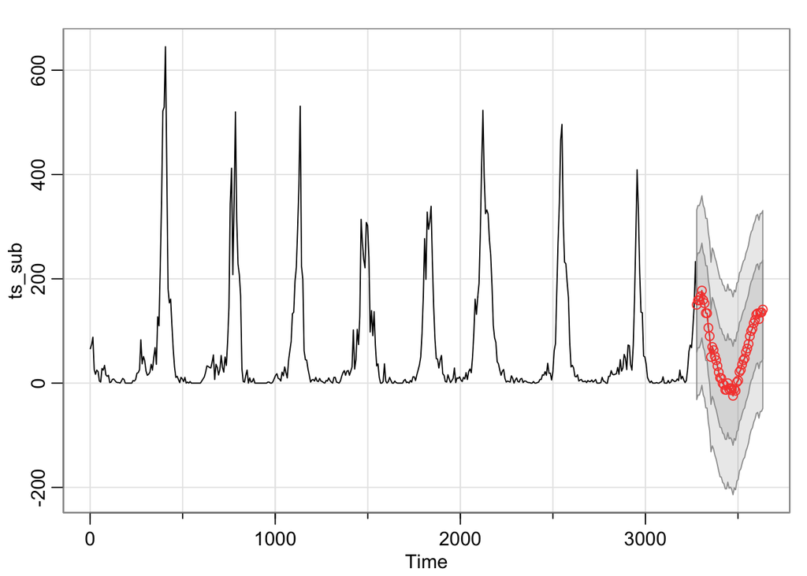

```
## $pred
## Time Series:
## Start = 3277
## End = 3634
## Frequency = 0.142857142857143
##  [1] 150.1573067 158.9339168 158.6655573 166.4464803 177.4710440 159.4423152
##  [7] 153.1258829 134.2533301 133.9086279 106.0883478  89.9554444  50.1324808
## [13]  69.3260116  63.3294608  51.5647592  43.9793548  32.7429934  20.9236584
## [19]  10.1657017   9.3349290  -0.6547911  -3.2145798 -12.8511907 -12.9472665
## [25]  -0.1370749 -11.8648376  -9.7299378 -13.7696867 -24.2583657 -11.3550816
## [31] -14.7446863   1.8724964   4.8898757  21.6709991  25.2853327  35.6127028
## [37]  43.8661039  47.3542603  59.5681769  66.2863582  75.2759622  89.8445056
## [43]  99.8722756 104.2518423 114.8802896 121.0228921 131.4259374 133.7277863
## [49] 122.6878247 135.1538665 135.6289737 141.1013346
##
## $se
## Time Series:
## Start = 3277
## End = 3634
## Frequency = 0.142857142857143
##  [1] 90.85544 90.85544 90.85544 90.85544 90.85544 90.85544 90.85544 90.85544
##  [9] 90.85544 90.85544 90.85544 90.85544 94.83857 94.83857 94.83857 94.83857
## [17] 94.83857 94.83857 94.83857 94.83857 94.83857 94.83857 94.83857 94.83857
## [25] 94.85791 94.85791 94.85791 94.85791 94.85791 94.85791 94.85791 94.85791
## [33] 94.85791 94.85791 94.85791 94.85791 94.87225 94.87225 94.87225 94.87225
## [41] 94.87225 94.87225 94.87225 94.87225 94.87225 94.87225 94.87225 94.87225
## [49] 94.86318 94.86318 94.86318 94.86318
```

```r
ts_sub <- ts[1:468]
sarima.for(ts_sub, n.ahead=52, p=0, d=0, q=0, P=2, D=0, Q=3, 12, plot.all=TRUE)
```

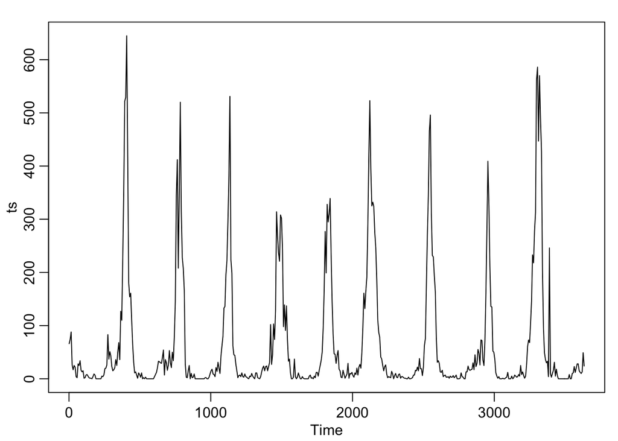

```r
ts.plot(ts)
```

Although it doesn’t match the actual results, it does provide a decent forecast. The beginning of the forecast provides a similar decreasing trend that we would see once the increase is finished. In addition, it makes sense that the forecast would rather decrease than increase in this instance. This is because the previous spikes were tailing off and not quite reaching a maximum level. But, the reality of this spike was that it did spike quite a bit more.

## Forecasting One Year Ahead

Next, we can use our original data to forecast one year into the future by using a similar process as before.

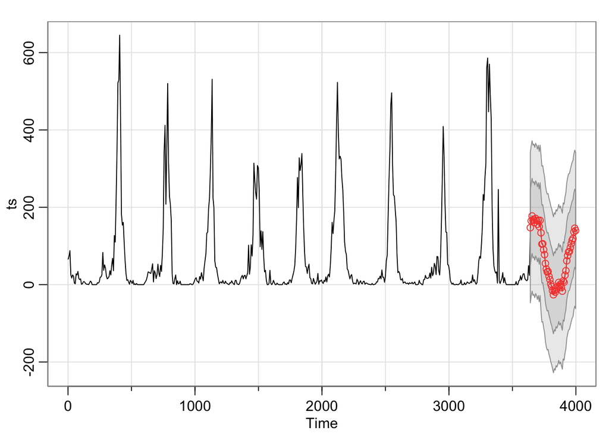

```
## $pred
## Time Series:
## Start = 3641
## End = 3998
## Frequency = 0.142857142857143
##  [1] 147.311191 164.998043 177.561705 166.366208 168.943520 160.661932
##  [7] 171.258904 165.728020 156.111138 166.104725 150.018024 166.225346
## [13] 133.988085 104.862179 105.728459  90.220166  77.602176  54.784288
## [19]  40.501963  32.624494  33.910819  21.608714  13.044812   1.845747
## [25]  -4.927189 -15.723238 -26.208489 -15.656425 -19.485511  -7.664103
## [31] -11.408802  -4.456433   5.689359  -3.718546   1.552120  -7.623849
## [37] -16.766384   9.687052   6.269734  24.322982  35.989623  61.650298
## [43]  74.999275  84.557094  85.742461  95.735681 105.569518 114.517840
## [49] 119.054928 136.273898 145.911288 139.769921
##
## $se
## Time Series:
## Start = 3641
## End = 3998
## Frequency = 0.142857142857143
##  [1]  97.19917  97.19917  97.19917  97.19917  97.19917  97.19917  97.19917
##  [8]  97.19917  97.17616  97.17616  97.17616  97.17616 100.81880 100.81880
## [15] 100.81880 100.81880 100.81880 100.81880 100.81880 100.81880 100.75164
## [22] 100.75164 100.75164 100.75164 100.83418 100.83418 100.83418 100.83418
## [29] 100.83418 100.83418 100.83418 100.83418 100.81645 100.81645 100.81645
## [36] 100.81645 100.88497 100.88497 100.88497 100.88497 100.88497 100.88497
## [43] 100.88497 100.88497 100.83378 100.83378 100.83378 100.83378 100.88353
## [50] 100.88353 100.88353 100.88353
```

```r
sarima.for(ts, n.ahead=52, p=0, d=0, q=0, P=2, D=0, Q=3, 12, plot.all=TRUE)
```

## Summary

Comparing the two forecasts, we see similar results. The first forecast displays the decreasing trend and follows it with an increasing spike. The second forecast follows suit as well. It displays the increasing results we expect, but does not quite reach the maximum values that are likely to occur; it proceeds to decrease. Due to the previous trend over the decade, we should expect to see one of the increased spikes occur when we forecast into the future. We do see an increase, but it’s not all that accurate.

While it may not be the most accurate, it does help Paris identify about when the next spike is going to occur. And based on previous data, they are able to determine about how large of an increase that should happen. In addition, we do see some negative values present in our forecast. This is not intuitive and not possible; therefore, a further investigation would be required to refine this model.

Overall, this SARIMA model does do well to match the trend of the data but is unable to display the most accurate prediction. This will be a good indicator for Paris to use to determine when the next spike is going to take place and how soon the spike is going to decrease. Determining the maximum and minimum values may be more difficult to be accurate for.